# PHÂN LOẠI CHỦ ĐỀ VĂN BẢN VỚI YAHOO ANSWERS

## 1. Giới thiệu về Tập dữ liệu (Introduction)

Tập dữ liệu Yahoo! Answers Topic Classification được trích xuất từ nghiên cứu của **Xiang Zhang, Junbo Zhao, và Yann LeCun (NIPS 2015)**.

- Quy mô: 1.400.000 mẫu huấn luyện và 60.000 mẫu kiểm thử.
- Cấu trúc: Mỗi mẫu bao gồm 3 phần văn bản: Tiêu đề (Title), Nội dung câu hỏi (Content) và Câu trả lời hay nhất (Best Answer).
- Số lớp: 10 lớp chủ đề từ Xã hội, Khoa học đến Chính trị.

## 2. Phương pháp nghiên cứu (Methodology)

Quy trình thực hiện bao gồm 4 giai đoạn logic để chuẩn bị cho mô hình RNN và Transformer:

1. **Thu thập & Cấu trúc hóa**: Tải dữ liệu từ Kaggle và sử dụng bộ nạp CSV tùy chỉnh để đảm bảo tính toàn vẹn của nội dung văn bản.
2. **Phân tích đặc điểm (EDA)**: Thống kê sự cân bằng các lớp và phân phối độ dài văn bản để xác định `padding` và `truncation` cho các chuỗi đầu vào.
3. **Tiền xử lý & Kiểm chứng**: Làm sạch nhiễu (HTML, Stopwords) và dùng N-grams/WordCloud để xác nhận dữ liệu vẫn giữ được ngữ nghĩa cốt lõi.
4. **Thiết lập dữ liệu**: Chia tập Train/Validation theo tỷ lệ 9/1 bằng phương pháp Stratified Sampling để đảm bảo tính khách quan và tránh Overfitting.

## 3. Hiện thực hóa quy trình (Implementation)

### 3.1. Cài đặt và Tải dữ liệu (Setup & Data Download)

Trong phần này, nhóm cài đặt thư viện `kagglehub` để tải tập dữ liệu trực tiếp từ Kaggle và thiết lập các thư viện cần thiết cho việc xử lý ngôn ngữ tự nhiên (NLP).

```python
import kagglehub
import pandas as pd
import csv
```

```python
# Download latest version
path = kagglehub.dataset_download("bhavikardeshna/yahoo-email-classification")

print("Path to dataset files:", path)
```

```
Path to dataset files: C:\Users\Admin\.cache\kagglehub\datasets\bhavikardeshna\yahoo-email-classification\versions\1
```

```python
import os

# Construct the full path to train.csv
train_path = os.path.join(path, "train.csv")
column_names = ['label', 'title', 'content', 'answer']

data = []
print("Loading data from kagglehub path...")

with open(train_path, 'r', encoding='utf-8', errors='ignore') as f:
    # Using the robust csv.reader method we perfected earlier
    reader = csv.reader(f, delimiter=',', quotechar='"')
    for row in reader:
        if len(row) >= 4:
            data.append(row[:4])

df = pd.DataFrame(data, columns=column_names)

# Standardize labels (0-9)
df['label'] = pd.to_numeric(df['label'], errors='coerce')
df = df.dropna(subset=['label'])
df['label'] = df['label'].astype(int) - 1

print(f"Successfully loaded {len(df)} samples from Kaggle.")
```

```
Loading data from kagglehub path...
Successfully loaded 1400000 samples from Kaggle.
```

### 3.2. Phân tích Dữ liệu Khám phá (Exploratory Data Analysis - EDA)

Chúng ta thực hiện phân tích sơ bộ để kiểm tra tính cân bằng của các lớp chủ đề và phân phối độ dài của văn bản, từ đó đưa ra các quyết định cho tham số của mô hình sau này.

#### 3.2.1. Trực quan hóa sự phân bổ các chủ đề

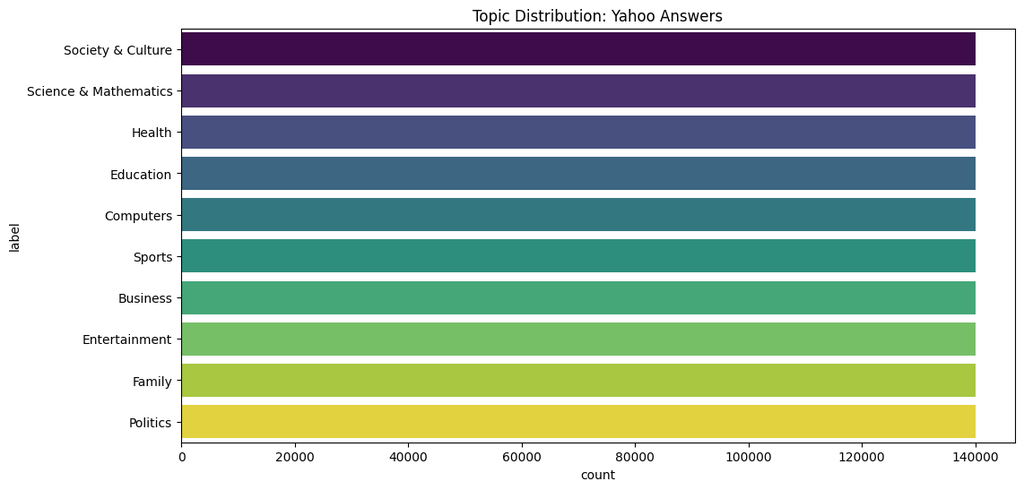

```python
# Visualize topic distribution to ensure class balance across the dataset
import matplotlib.pyplot as plt
import seaborn as sns
topic_names = ["Society & Culture", "Science & Mathematics", "Health", "Education",
               "Computers", "Sports", "Business", "Entertainment", "Family", "Politics"]

plt.figure(figsize=(12, 6))
sns.countplot(y='label', data=df, palette='viridis', hue='label', legend=False)
plt.yticks(ticks=range(10), labels=topic_names)
plt.title('Topic Distribution: Yahoo Answers')
plt.show()
```

#### 3.2.2. Thông số thống kê về độ dài văn bản

```python
# Combine text fields and calculate descriptive statistics for word counts
df[['title', 'content', 'answer']] = df[['title', 'content', 'answer']].fillna("")
df['full_text'] = df['title'] + " " + df['content'] + " " + df['answer']
df['text_len'] = df['full_text'].apply(lambda x: len(str(x).split()))

print(f"Average: {df['text_len'].mean():.2f} words")
print(f"95th percentile: {df['text_len'].quantile(0.95):.2f} words")
```

```
Average: 91.56 words
95th percentile: 273.00 words
```

#### 3.2.3. Xác định ngưỡng cắt (`max_seq_len`) tối ưu cho RNN và Transformer.

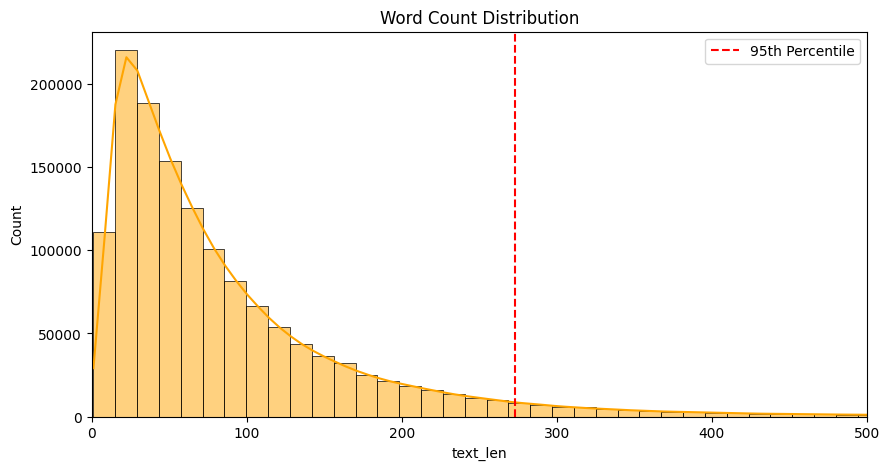

```python
# Visualize word count distribution and the 95th percentile threshold
plt.figure(figsize=(10, 5))
sns.histplot(df['text_len'], bins=100, kde=True, color='orange')
plt.axvline(df['text_len'].quantile(0.95), color='r', linestyle='--', label='95th Percentile')
plt.title('Word Count Distribution')
plt.xlim(0, 500)
plt.legend()
plt.show()
```

#### 3.2.4. Xác định độ dài ngưỡng tối đa

```python
# Set max_seq_len at the 95th percentile to cover most samples efficiently
MAX_SEQ_LEN = int(df['text_len'].quantile(0.95))
print(f"Final MAX_SEQ_LEN: {MAX_SEQ_LEN}")
```

```
Final MAX_SEQ_LEN: 273
```

### 3.3. Tiền xử lý văn bản (Text Preprocessing)

#### 3.3.1. Làm sạch dữ liệu văn bản

Loại bỏ nhiễu (thẻ HTML, ký tự đặc biệt) và chuẩn hóa văn bản về dạng chữ thường để giảm kích thước từ điển cho mô hình.

```python
import re
import nltk
from nltk.corpus import stopwords
nltk.download('stopwords')
stop_words = set(stopwords.words('english'))

def clean_text_final(text):
    text = str(text).lower()
    # 1. Remove HTML tags (important for Yahoo Answers)
    text = re.sub(r'<.*?>', '', text)
    # 2. Remove special characters/numbers
    text = re.sub(r'[^a-z\s]', '', text)
    # 3. Remove stopwords
    words = [w for w in text.split() if w not in stop_words]
    return " ".join(words)

# Apply to the cleaned_text column
df['cleaned_text'] = df['full_text'].apply(clean_text_final)
```

#### 3.3.2. Kiểm tra dữ liệu trùng lặp và tần suất từ

Thống kê các mẫu bị trùng và phân tích các từ đơn xuất hiện nhiều nhất để đảm bảo dữ liệu đã được làm sạch hiệu quả.

```
Number of duplicate samples: 1020
```

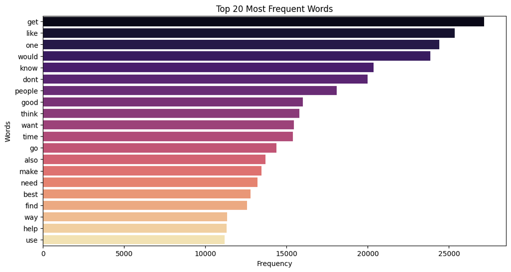

```python
from collections import Counter

# Count duplicate samples based on cleaned text
duplicates = df.duplicated(subset=['cleaned_text']).sum()
print(f"Number of duplicate samples: {duplicates}")

# Calculate word frequency for the top 100,000 samples
all_words = " ".join(df['cleaned_text'].iloc[:100000]).split()
word_freq = Counter(all_words)

# Visualize the Top 20 most frequent words
common_words = word_freq.most_common(20)
words, counts = zip(*common_words)

plt.figure(figsize=(12, 6))
sns.barplot(x=list(counts), y=list(words), palette='magma', legend=False)
plt.title('Top 20 Most Frequent Words')
plt.xlabel('Frequency')
plt.ylabel('Words')
plt.show()
```

#### 3.3.3. Phân tích cụm từ phổ biến (N-gram Analysis)

Sử dụng Bi-grams để quan sát các cụm hai từ đi kèm nhau, giúp hiểu sâu hơn về ngữ cảnh của các chủ đề trong tập dữ liệu.

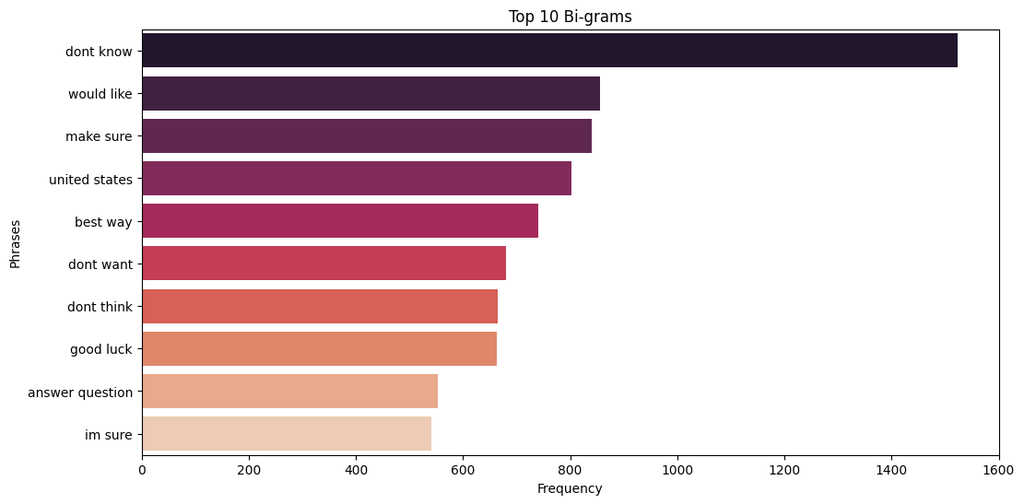

```python
from sklearn.feature_extraction.text import CountVectorizer

def get_top_ngram(corpus, n=None, top_k=10):
    """Function to extract the top k n-grams from the corpus"""
    vec = CountVectorizer(ngram_range=(n, n)).fit(corpus)
    bag_of_words = vec.transform(corpus)
    sum_words = bag_of_words.sum(axis=0)
    words_freq = [(word, sum_words[0, idx]) for word, idx in vec.vocabulary_.items()]
    words_freq = sorted(words_freq, key = lambda x: x[1], reverse=True)
    return words_freq[:top_k]

# Extract and visualize Top 10 Bi-grams (2-word phrases)
top_bi_grams = get_top_ngram(df['cleaned_text'].iloc[:50000], n=2)
words_bi, counts_bi = zip(*top_bi_grams)

plt.figure(figsize=(12, 6))
sns.barplot(x=list(counts_bi), y=list(words_bi), palette='rocket')
plt.title('Top 10 Bi-grams')
plt.xlabel('Frequency')
plt.ylabel('Phrases')
plt.show()
```

#### 3.3.4. Kiểm chứng dữ liệu sau khi làm sạch

Sử dụng biểu đồ WordCloud để quan sát trực quan các từ khóa đặc trưng nhất trong tập dữ liệu sau khi loại bỏ nhiễu.

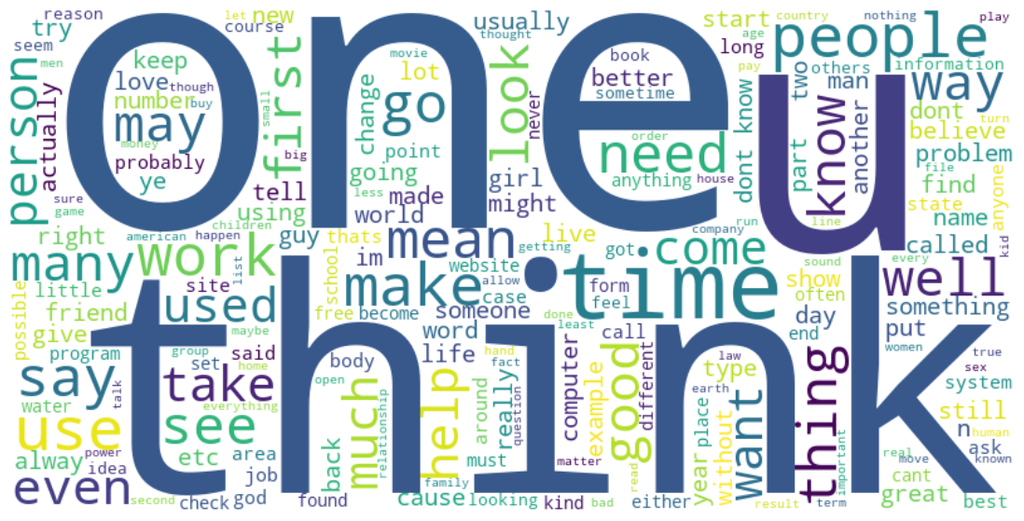

```python
from wordcloud import WordCloud

# Create wordcloud for the whole data or for each topic
wordcloud = WordCloud(width=800, height=400, background_color='white').generate(" ".join(all_words))

plt.figure(figsize=(15, 7))
plt.imshow(wordcloud, interpolation='bilinear')
plt.axis('off')
plt.show()
```

### 3.4. Phân tách và Lưu trữ Dữ liệu (Data Splitting & Final Storage)

#### 3.4.1. Chuẩn hóa nhãn và Làm sạch lần cuối

Đảm bảo nhãn dữ liệu ở định dạng số nguyên và loại bỏ triệt để các mẫu dữ liệu trống sau quá trình xử lý văn bản.

```python
# Ensure the label is in integer format (0-9) for compatibility with Loss Functions
df['label'] = df['label'].astype(int)

# Remove any rows that might have become empty or contain only whitespace after cleaning
df = df.dropna(subset=['cleaned_text'])
df = df[df['cleaned_text'].str.strip() != ""]

# Select only necessary columns to optimize memory usage
df_final = df[['label', 'cleaned_text']].reset_index(drop=True)

print(f"Data ready for splitting. Total samples: {df_final.shape[0]}")
```

```
Data ready for splitting. Total samples: 1399831
```

#### 3.4.2. Phân tách tập dữ liệu Huấn luyện và Kiểm định

Sử dụng phương pháp *Stratified Split* để chia dữ liệu theo tỷ lệ 9:1, đảm bảo sự cân bằng giữa các chủ đề trong cả hai tập.

```python
from sklearn.model_selection import train_test_split

# We split the dataset into 90% Training and 10% Validation
# 'stratify' ensures that each topic is represented proportionally in both sets
train_df, val_df = train_test_split(
    df_final,
    test_size=0.1,
    random_state=42,
    stratify=df_final['label']
)

print(f"Training samples: {len(train_df)}")
print(f"Validation samples: {len(val_df)}")
```

```
Training samples: 1259847
Validation samples: 139984
```

#### 3.4.3. Lưu trữ dữ liệu đã xử lý

Xuất dữ liệu ra file CSV để có thể tái sử dụng nhanh chóng mà không cần thực hiện lại toàn bộ quy trình tiền xử lý.

```python
# Saving the cleaned datasets locally or to Google Drive to avoid re-processing
# index=False prevents pandas from adding an extra 'unnamed' column
train_df.to_csv('yahoo_train_final.csv', index=False)
val_df.to_csv('yahoo_val_final.csv', index=False)

print("Processed datasets have been saved successfully!")
```

```
Processed datasets have been saved successfully!
```

```python
import pandas as pd
import numpy as np
import torch
import torch.nn as nn
from torch.utils.data import Dataset, DataLoader
from sklearn.metrics import accuracy_score, f1_score
from transformers import AutoTokenizer, AutoModelForSequenceClassification
```

```python
# ---------------------------------------------------------
# 1. THIẾT LẬP THIẾT BỊ (CUDA) & TẢI DỮ LIỆU
# ---------------------------------------------------------
device = torch.device('cuda' if torch.cuda.is_available() else 'cpu')
print(f"Đang chạy trên thiết bị: {device}")

# Tải lại dữ liệu đã qua xử lý của bạn
train_df = pd.read_csv('yahoo_train_final.csv').fillna("")
val_df = pd.read_csv('yahoo_val_final.csv').fillna("")

# Số lượng nhãn của tập Yahoo Answers là 10
NUM_CLASSES = 10
MAX_SEQ_LEN = 150 # Có thể dùng giá trị bách phân vị 95 bạn đã tính trước đó
```

```
Đang chạy trên thiết bị: cuda
```

```python
BATCH_SIZE = 128
# ---------------------------------------------------------
# 2. CHUẨN BỊ DỮ LIỆU CHO LSTM (Tự xây dựng từ vựng thuần Python)
# ---------------------------------------------------------
from collections import Counter

def basic_tokenizer(text):
    # Dữ liệu của bạn đã được làm sạch ở bước trước nên chỉ cần split
    return str(text).split()

def build_vocab(texts, max_vocab_size=20000):
    counter = Counter()
    for text in texts:
        counter.update(basic_tokenizer(text))

    # Khởi tạo từ điển với các token đặc biệt
    vocab = {"<pad>": 0, "<unk>": 1}

    # Lấy các từ phổ biến nhất đưa vào từ điển
    for word, _ in counter.most_common(max_vocab_size):
        if word not in vocab:
            vocab[word] = len(vocab)
    return vocab

print("Đang xây dựng tập từ vựng cho LSTM...")
vocab = build_vocab(train_df['cleaned_text'])
print(f"Kích thước tập từ vựng: {len(vocab)} từ")

class LSTMDataset(Dataset):
    def __init__(self, texts, labels, vocab, max_len):
        self.texts = texts
        self.labels = labels
        self.vocab = vocab
        self.max_len = max_len

    def __len__(self):
        return len(self.texts)

    def __getitem__(self, idx):
        text = str(self.texts.iloc[idx])
        label = self.labels.iloc[idx]

        # Chuyển đổi text thành các con số (indices), nếu từ lạ thì gán là <unk>
        tokens = [self.vocab.get(w, self.vocab["<unk>"]) for w in basic_tokenizer(text)]

        # Padding hoặc Truncating
        if len(tokens) < self.max_len:
            tokens += [self.vocab["<pad>"]] * (self.max_len - len(tokens))
        else:
            tokens = tokens[:self.max_len]

        return torch.tensor(tokens, dtype=torch.long), torch.tensor(label, dtype=torch.long)



# Cập nhật DataLoader cho LSTM
train_loader_lstm = DataLoader(LSTMDataset(train_df['cleaned_text'], train_df['label'], vocab, MAX_SEQ_LEN),
                               batch_size=BATCH_SIZE, shuffle=True, pin_memory=True)
val_loader_lstm = DataLoader(LSTMDataset(val_df['cleaned_text'], val_df['label'], vocab, MAX_SEQ_LEN),
                             batch_size=BATCH_SIZE, pin_memory=True)
```

```
Đang xây dựng tập từ vựng cho LSTM...
Kích thước tập từ vựng: 20002 từ
```

```python
# ---------------------------------------------------------
# 3. ĐỊNH NGHĨA MÔ HÌNH LSTM
# ---------------------------------------------------------
class LSTMClassifier(nn.Module):
    def __init__(self, vocab_size, embed_dim, hidden_dim, num_classes):
        super(LSTMClassifier, self).__init__()
        self.embedding = nn.Embedding(vocab_size, embed_dim, padding_idx=vocab["<pad>"])
        # batch_first=True giúp đầu vào có định dạng (batch, seq, feature)
        self.lstm = nn.LSTM(embed_dim, hidden_dim, num_layers=2, batch_first=True, bidirectional=True, dropout=0.3)
        self.fc = nn.Linear(hidden_dim * 2, num_classes) # *2 vì bidirectional

    def forward(self, x):
        embedded = self.embedding(x)
        lstm_out, (hidden, cell) = self.lstm(embedded)
        # Lấy hidden state của lớp cuối cùng để phân loại
        hidden_cat = torch.cat((hidden[-2,:,:], hidden[-1,:,:]), dim=1)
        return self.fc(hidden_cat)

model_lstm = LSTMClassifier(len(vocab), embed_dim=128, hidden_dim=256, num_classes=NUM_CLASSES).to(device)
```

```python
# ---------------------------------------------------------
# 4. CHUẨN BỊ DỮ LIỆU & MÔ HÌNH TRANSFORMER (Pretrained DistilBERT)
# ---------------------------------------------------------
model_name = "distilbert-base-uncased"
tokenizer_tf = AutoTokenizer.from_pretrained(model_name)

class TransformerDataset(Dataset):
    def __init__(self, texts, labels, tokenizer, max_len):
        self.texts = texts
        self.labels = labels
        self.tokenizer = tokenizer
        self.max_len = max_len

    def __len__(self):
        return len(self.texts)

    def __getitem__(self, idx):
        text = str(self.texts.iloc[idx])
        label = self.labels.iloc[idx]

        # SỬA LỖI TẠI ĐÂY: Dùng trực tiếp self.tokenizer() thay vì self.tokenizer.encode_plus()
        encoding = self.tokenizer(
            text,
            add_special_tokens=True,
            max_length=self.max_len,
            padding='max_length',
            truncation=True,
            return_attention_mask=True,
            return_tensors='pt',
        )
        return {
            'input_ids': encoding['input_ids'].flatten(),
            'attention_mask': encoding['attention_mask'].flatten(),
            'labels': torch.tensor(label, dtype=torch.long)
        }

# Chạy lại 2 dòng này để nạp lại dữ liệu với class mới vừa sửa
train_loader_tf = DataLoader(TransformerDataset(train_df['cleaned_text'], train_df['label'], tokenizer_tf, MAX_SEQ_LEN), batch_size=BATCH_SIZE, shuffle=True, pin_memory=True)
val_loader_tf = DataLoader(TransformerDataset(val_df['cleaned_text'], val_df['label'], tokenizer_tf, MAX_SEQ_LEN), batch_size=BATCH_SIZE, pin_memory=True)

train_loader_tf = DataLoader(TransformerDataset(train_df['cleaned_text'], train_df['label'], tokenizer_tf, MAX_SEQ_LEN),
                             batch_size=BATCH_SIZE, shuffle=True, pin_memory=True)
val_loader_tf = DataLoader(TransformerDataset(val_df['cleaned_text'], val_df['label'], tokenizer_tf, MAX_SEQ_LEN),
                           batch_size=BATCH_SIZE, pin_memory=True)
# Tải mô hình pretrained cho Sequence Classification
model_tf = AutoModelForSequenceClassification.from_pretrained(model_name, num_labels=NUM_CLASSES).to(device)
```

[output not shown]

```python
import copy
from tqdm.auto import tqdm
from sklearn.metrics import accuracy_score, f1_score

# ---------------------------------------------------------
# 5. VÒNG LẶP HUẤN LUYỆN (In đầy đủ Train/Val Accuracy & Early Stopping)
# ---------------------------------------------------------
def train_and_evaluate(model, train_loader, val_loader, model_type="lstm", epochs=20, patience=3):
    criterion = nn.CrossEntropyLoss()
    optimizer = torch.optim.AdamW(model.parameters(), lr=2e-5 if model_type=="transformer" else 1e-3)

    print(f"\n{'='*55}")
    print(f"🚀 BẮT ĐẦU HUẤN LUYỆN: {model_type.upper()} (Max Epochs: {epochs}, Patience: {patience})")
    print(f"{'='*55}")

    best_val_loss = float('inf')
    patience_counter = 0
    best_model_state = None

    for epoch in range(epochs):
        # ==========================================
        # 1. PHA HUẤN LUYỆN (TRAINING)
        # ==========================================
        model.train()
        total_train_loss = 0
        train_preds, train_labels_list = [], [] # Thêm mảng lưu kết quả Train

        train_progress = tqdm(train_loader, desc=f"Epoch {epoch+1}/{epochs} [Train]", leave=False)
        for batch in train_progress:
            optimizer.zero_grad()

            if model_type == "lstm":
                inputs, labels = batch[0].to(device), batch[1].to(device)
                outputs = model(inputs)
            else: # transformer
                inputs = batch['input_ids'].to(device)
                masks = batch['attention_mask'].to(device)
                labels = batch['labels'].to(device)
                outputs = model(inputs, attention_mask=masks).logits

            loss = criterion(outputs, labels)
            loss.backward()
            optimizer.step()
            total_train_loss += loss.item()

            # Lưu lại dự đoán để tính Train Accuracy (Dùng detach để tránh tràn RAM)
            preds = torch.argmax(outputs, dim=1).detach().cpu().numpy()
            train_preds.extend(preds)
            train_labels_list.extend(labels.cpu().numpy())

            train_progress.set_postfix({"loss": f"{loss.item():.4f}"})

        # Tính Train Accuracy
        train_acc = accuracy_score(train_labels_list, train_preds)

        # ==========================================
        # 2. PHA ĐÁNH GIÁ (VALIDATION)
        # ==========================================
        model.eval()
        total_val_loss = 0
        val_preds, val_labels_list = [], []

        val_progress = tqdm(val_loader, desc=f"Epoch {epoch+1}/{epochs} [Val]  ", leave=False)
        with torch.no_grad():
            for batch in val_progress:
                if model_type == "lstm":
                    inputs, labels = batch[0].to(device), batch[1].to(device)
                    outputs = model(inputs)
                else:
                    inputs = batch['input_ids'].to(device)
                    masks = batch['attention_mask'].to(device)
                    labels = batch['labels'].to(device)
                    outputs = model(inputs, attention_mask=masks).logits

                val_loss = criterion(outputs, labels)
                total_val_loss += val_loss.item()

                preds = torch.argmax(outputs, dim=1).cpu().numpy()
                val_preds.extend(preds)
                val_labels_list.extend(labels.cpu().numpy())

        # ==========================================
        # 3. TỔNG HỢP VÀ IN KẾT QUẢ EPOCH
        # ==========================================
        avg_train_loss = total_train_loss / len(train_loader)
        avg_val_loss = total_val_loss / len(val_loader)
        val_acc = accuracy_score(val_labels_list, val_preds)
        val_f1 = f1_score(val_labels_list, val_preds, average='macro')

        print(f"✅ TỔNG KẾT EPOCH {epoch+1}/{epochs}:")
        print(f"   - Train Loss : {avg_train_loss:.4f} | Train Acc: {train_acc:.4f}")
        print(f"   - Val Loss   : {avg_val_loss:.4f} | Val Acc  : {val_acc:.4f} | Val F1: {val_f1:.4f}")

        # --- KIỂM TRA EARLY STOPPING ---
        if avg_val_loss < best_val_loss:
            best_val_loss = avg_val_loss
            patience_counter = 0
            best_model_state = copy.deepcopy(model.state_dict())
            print(f"   ⭐ Validation Loss giảm. Đã lưu lại mô hình tốt nhất!")
        else:
            patience_counter += 1
            print(f"   ⚠️ Validation Loss không giảm. Patience: {patience_counter}/{patience}")

        if patience_counter >= patience:
            print(f"\n🛑 Kích hoạt EARLY STOPPING tại Epoch {epoch+1}! Mô hình bắt đầu có dấu hiệu Overfitting.")
            break
        print("-" * 55)

    # ==========================================
    # 4. KHÔI PHỤC TRỌNG SỐ TỐT NHẤT TRƯỚC KHI KẾT THÚC
    # ==========================================
    if best_model_state is not None:
        model.load_state_dict(best_model_state)
        print("\n🔄 Đã khôi phục trọng số của epoch có Validation Loss thấp nhất.")

    return val_acc, val_f1
```

```python
# ---------------------------------------------------------
# 6. THỰC THI & SO SÁNH
# ---------------------------------------------------------
# LSTM train từ đầu nên để số epoch tối đa lớn (20), Early Stopping sẽ tự ngắt khi đủ chín
lstm_acc, lstm_f1 = train_and_evaluate(model_lstm, train_loader_lstm, val_loader_lstm,
                                       model_type="lstm", epochs=20, patience=3)
print(f"LSTM        -> Accuracy: {lstm_acc:.4f} | F1-Score: {lstm_f1:.4f}")
```

```
=======================================================
🚀 BẮT ĐẦU HUẤN LUYỆN: LSTM (Max Epochs: 20, Patience: 3)
=======================================================
```

```
✅ TỔNG KẾT EPOCH 1/20:
   - Train Loss : 0.5438 | Train Acc: 0.8172
   - Val Loss   : 0.9442 | Val Acc  : 0.7141 | Val F1: 0.7112
   ⭐ Validation Loss giảm. Đã lưu lại mô hình tốt nhất!
-------------------------------------------------------
```

```
✅ TỔNG KẾT EPOCH 2/20:
   - Train Loss : 0.5205 | Train Acc: 0.8241
   - Val Loss   : 0.9675 | Val Acc  : 0.7113 | Val F1: 0.7090
   ⚠️ Validation Loss không giảm. Patience: 1/3
-------------------------------------------------------
```

```
✅ TỔNG KẾT EPOCH 3/20:
   - Train Loss : 0.5000 | Train Acc: 0.8310
   - Val Loss   : 0.9983 | Val Acc  : 0.7072 | Val F1: 0.7059
   ⚠️ Validation Loss không giảm. Patience: 2/3
-------------------------------------------------------
```

[output not shown]

[output not shown]

[output cut: 30 more lines]

[output not shown]

```python
# ---------------------------------------------------------
# 6. THỰC THI & SO SÁNH
# ---------------------------------------------------------

# Transformer dùng fine-tune nên chỉ cần khoảng 3-4 epoch là đủ, để max=5
tf_acc, tf_f1 = train_and_evaluate(model_tf, train_loader_tf, val_loader_tf,
                                   model_type="transformer", epochs=5, patience=2)
print(f"Transformer -> Accuracy: {tf_acc:.4f} | F1-Score: {tf_f1:.4f}")
```

```
=======================================================
🚀 BẮT ĐẦU HUẤN LUYỆN: TRANSFORMER (Max Epochs: 5, Patience: 2)
=======================================================
```

```
✅ TỔNG KẾT EPOCH 1/5:
   - Train Loss : 0.8047 | Train Acc: 0.7403
   - Val Loss   : 0.7468 | Val Acc  : 0.7562 | Val F1: 0.7513
   ⭐ Validation Loss giảm. Đã lưu lại mô hình tốt nhất!
-------------------------------------------------------
```

```
✅ TỔNG KẾT EPOCH 2/5:
   - Train Loss : 0.7097 | Train Acc: 0.7673
   - Val Loss   : 0.7353 | Val Acc  : 0.7606 | Val F1: 0.7568
   ⭐ Validation Loss giảm. Đã lưu lại mô hình tốt nhất!
-------------------------------------------------------
```

```
✅ TỔNG KẾT EPOCH 3/5:
   - Train Loss : 0.6509 | Train Acc: 0.7853
   - Val Loss   : 0.7455 | Val Acc  : 0.7594 | Val F1: 0.7545
   ⚠️ Validation Loss không giảm. Patience: 1/2
-------------------------------------------------------
```

```
✅ TỔNG KẾT EPOCH 4/5:
   - Train Loss : 0.5912 | Train Acc: 0.8042
   - Val Loss   : 0.7684 | Val Acc  : 0.7547 | Val F1: 0.7503
   ⚠️ Validation Loss không giảm. Patience: 2/2

🛑 Kích hoạt EARLY STOPPING tại Epoch 4! Mô hình bắt đầu có dấu hiệu Overfitting.

🔄 Đã khôi phục trọng số của epoch có Validation Loss thấp nhất.
Transformer -> Accuracy: 0.7547 | F1-Score: 0.7503
```

```
💾 Đang lưu trọng số mô hình tốt nhất xuống ổ cứng...
✅ Đã lưu thành công: 'lstm_best_model.pt' và 'transformer_best_model.pt'

🔍 Đang trích xuất dự đoán từ mô hình LSTM trên tập Validation...
🔍 Đang trích xuất dự đoán từ mô hình Transformer trên tập Validation...
```

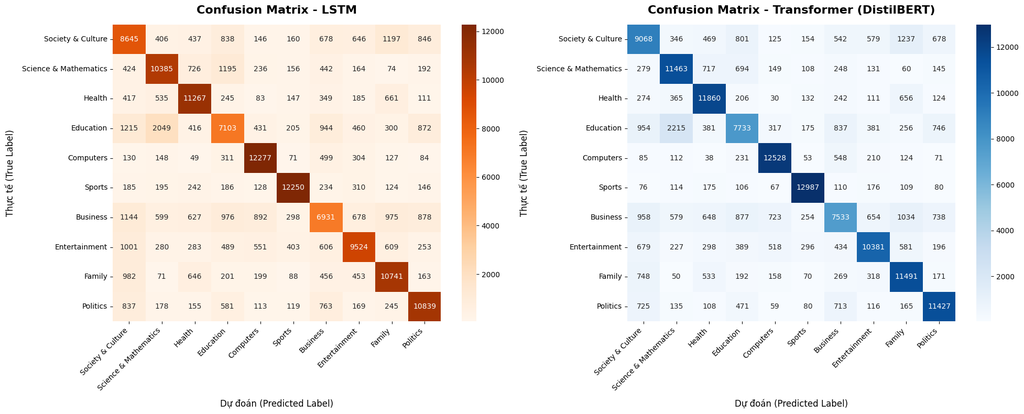

```python
import torch
import matplotlib.pyplot as plt
import seaborn as sns
from sklearn.metrics import confusion_matrix

# =========================================================
# 7. LƯU TRỌNG SỐ MÔ HÌNH (SAVE MODELS)
# =========================================================
print("💾 Đang lưu trọng số mô hình tốt nhất xuống ổ cứng...")

# Lưu mô hình LSTM
torch.save(model_lstm.state_dict(), 'lstm_best_model.pt')

# Lưu mô hình Transformer
torch.save(model_tf.state_dict(), 'transformer_best_model.pt')

print("✅ Đã lưu thành công: 'lstm_best_model.pt' và 'transformer_best_model.pt'")

# =========================================================
# 8. TRÍCH XUẤT DỰ ĐOÁN (PREDICTIONS) TỪ 2 MÔ HÌNH
# =========================================================
def get_predictions(model, data_loader, model_type="lstm"):
    """Hàm chạy mô hình trên tập dữ liệu để lấy danh sách dự đoán"""
    model.eval()
    all_preds = []
    all_labels = []

    with torch.no_grad():
        for batch in data_loader:
            if model_type == "lstm":
                inputs, labels = batch[0].to(device), batch[1].to(device)
                outputs = model(inputs)
            else: # transformer
                inputs = batch['input_ids'].to(device)
                masks = batch['attention_mask'].to(device)
                labels = batch['labels'].to(device)
                outputs = model(inputs, attention_mask=masks).logits

            preds = torch.argmax(outputs, dim=1).cpu().numpy()
            all_preds.extend(preds)
            all_labels.extend(labels.cpu().numpy())

    return all_labels, all_preds

# Trích xuất cho LSTM
print("\n🔍 Đang trích xuất dự đoán từ mô hình LSTM trên tập Validation...")
y_true_lstm, y_pred_lstm = get_predictions(model_lstm, val_loader_lstm, model_type="lstm")

# Trích xuất cho Transformer
print("🔍 Đang trích xuất dự đoán từ mô hình Transformer trên tập Validation...")
y_true_tf, y_pred_tf = get_predictions(model_tf, val_loader_tf, model_type="transformer")

# =========================================================
# 9. VẼ ĐỒ THỊ CONFUSION MATRIX (SIDE-BY-SIDE)
# =========================================================
# Tên các chủ đề
topic_names = ["Society & Culture", "Science & Mathematics", "Health", "Education",
               "Computers", "Sports", "Business", "Entertainment", "Family", "Politics"]

# Tính toán 2 ma trận nhầm lẫn
cm_lstm = confusion_matrix(y_true_lstm, y_pred_lstm)
cm_tf = confusion_matrix(y_true_tf, y_pred_tf)

# Khởi tạo figure với 2 đồ thị con (1 hàng, 2 cột)
fig, axes = plt.subplots(1, 2, figsize=(20, 8))

# ---- Đồ thị 1: LSTM (Tông màu Cam) ----
sns.heatmap(cm_lstm, annot=True, fmt='d', cmap='Oranges',
            xticklabels=topic_names, yticklabels=topic_names, ax=axes[0])
axes[0].set_title('Confusion Matrix - LSTM', fontsize=16, fontweight='bold', pad=15)
axes[0].set_xlabel('Dự đoán (Predicted Label)', fontsize=12, labelpad=10)
axes[0].set_ylabel('Thực tế (True Label)', fontsize=12, labelpad=10)
axes[0].set_xticklabels(axes[0].get_xticklabels(), rotation=45, ha='right')

# ---- Đồ thị 2: Transformer (Tông màu Xanh) ----
sns.heatmap(cm_tf, annot=True, fmt='d', cmap='Blues',
            xticklabels=topic_names, yticklabels=topic_names, ax=axes[1])
axes[1].set_title('Confusion Matrix - Transformer (DistilBERT)', fontsize=16, fontweight='bold', pad=15)
axes[1].set_xlabel('Dự đoán (Predicted Label)', fontsize=12, labelpad=10)
axes[1].set_ylabel('Thực tế (True Label)', fontsize=12, labelpad=10)
axes[1].set_xticklabels(axes[1].get_xticklabels(), rotation=45, ha='right')

# Căn chỉnh khoảng cách giữa 2 đồ thị cho đẹp
plt.tight_layout()
plt.show()
```